# Introducción a la programación y análisis de datos en R

## Paso 5 (extra): paletas de colores

Los colores por defecto de `ggplot2` se cambian con una capa `scale_fill_*()` (o `scale_color_*()` para contornos y puntos). Para elegir: [buscador de paletas de la R Graph Gallery](https://r-graph-gallery.com/color-palette-finder).

```r
# viridis: viene con ggplot2;
# legible en gris y
# para daltonicos
grafico_ansiedad +
  theme_classic() +
  scale_fill_viridis_d()
```

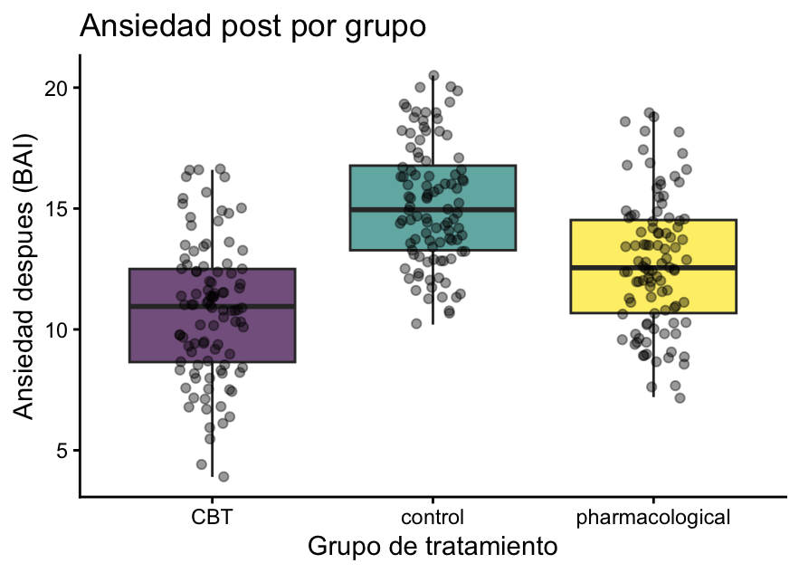

[Las paletas de viridis](https://ggplot2.tidyverse.org/reference/scale_viridis.html)

```r
# ggsci: paletas de revistas
# (Lancet, NEJM, Nature...)
library(ggsci)
grafico_ansiedad +
  theme_classic() +
  scale_fill_lancet()
```

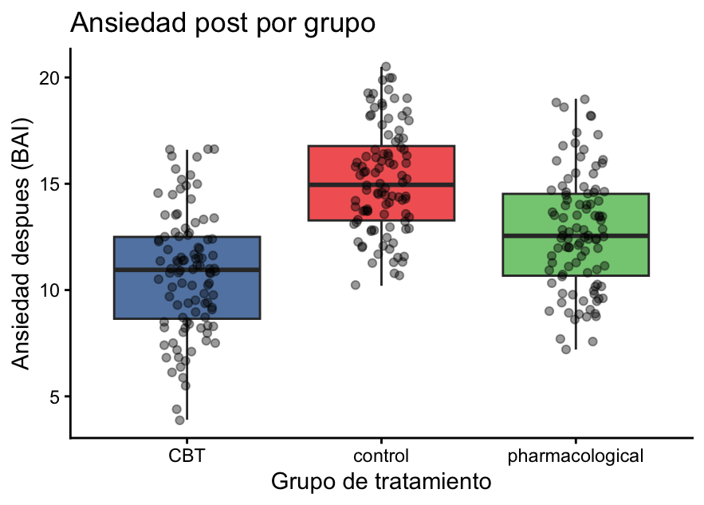

[Todas las paletas de ggsci](https://nanx.me/ggsci/articles/ggsci.html)

```r
# harrypotter: una paleta
# por casa de Hogwarts
library(harrypotter)
grafico_ansiedad +
  theme_classic() +
  scale_fill_hp_d(
    option = "Ravenclaw")
```

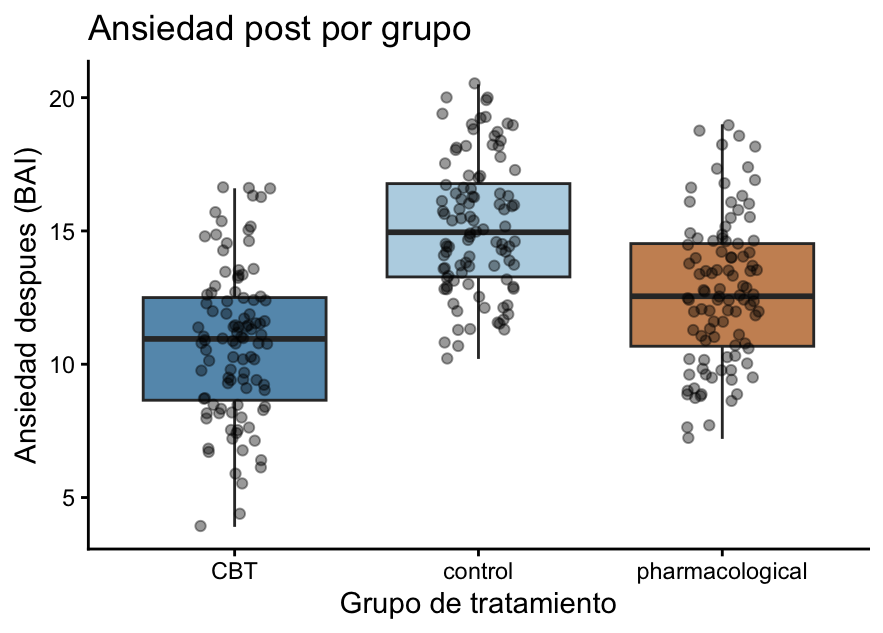

[Las casas y otras paletas de harrypotter](https://github.com/aljrico/harrypotter)

En este deck todos los gráficos usan **Okabe-Ito** (apta para daltónicos), fijada una vez al principio: `options(ggplot2.discrete.fill = palette.colors(palette = "Okabe-Ito")[-1])` (y lo mismo con `ggplot2.discrete.colour`)

## Paso 6: Extra: añadir usar `facets`

```r
# para comparar pre y post hace falta
# el formato largo (dia 3)
datos_largo <- data_trial |>
  pivot_longer(cols = c(anxiety_pre, anxiety_post),
               names_to = "momento",
               values_to = "anxiety",
               names_prefix = "anxiety_") |>
  mutate(momento = factor(momento,
                          levels = c("pre", "post")))

grafico_pre_post <- ggplot(data = datos_largo,
       mapping = aes(x = group, y = anxiety,
                     fill = group)) +
  geom_boxplot(alpha = 0.7, outliers = FALSE) +
  geom_jitter(width = 0.15, alpha = 0.4) +
  labs(x = "Grupo", y = "Ansiedad (BAI)") +
  theme_classic() +
  theme(legend.position = "none") +
  facet_wrap(~ momento)
```

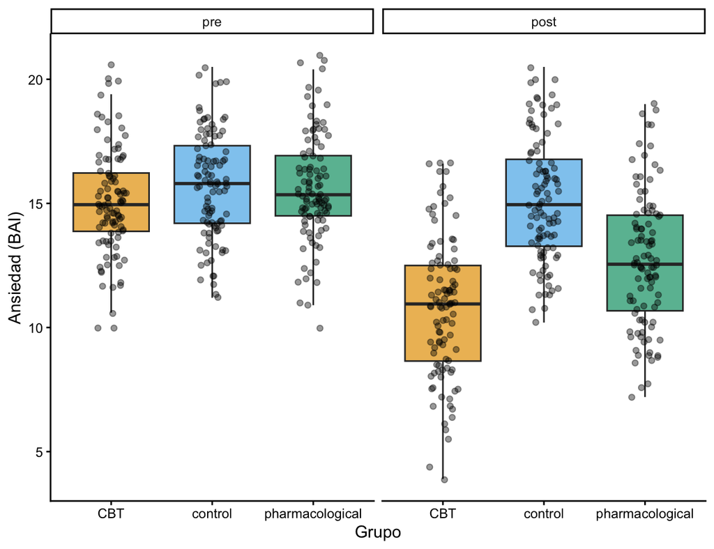

```r
grafico_pre_post
```

- `facet_wrap()` separa el gráfico en paneles, uno por nivel de la variable (aquí, `momento`), con los **mismos ejes**, para poder compararlos
- Los paneles siguen el **orden de los niveles** del factor: sin el `factor(levels = ...)`, `momento` sería texto y saldría por orden alfabético, “post” antes que “pre”
- Es el gráfico del ANOVA mixto del día 3: antes no hay diferencias entre grupos, después sí

## Combinar gráficos: `patchwork`

Los gráficos son objetos y `patchwork` los **suma**: `|` (o `+`) lado a lado, `/` uno sobre otro, paréntesis para anidar (`(a | b) / c`); `plot_annotation(tag_levels = "A")` pone las letras de los paneles.

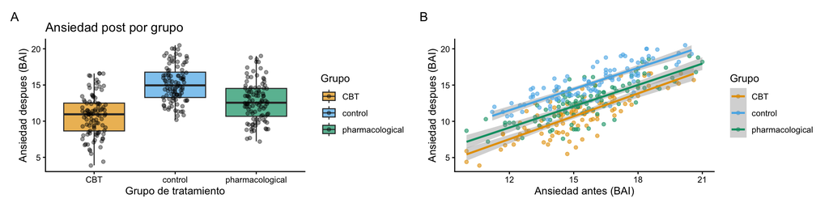

```r
library(patchwork)   # install.packages("patchwork")

# un segundo grafico: ansiedad antes frente a despues, una recta por grupo
grafico_puntos <- ggplot(data = data_trial,
                         mapping = aes(x = anxiety_pre, y = anxiety_post, color = group)) +
  geom_point(alpha = 0.6) +            # cada paciente
  geom_smooth(method = "lm") +         # recta de regresion (una por grupo, por el color)
  labs(x = "Ansiedad antes (BAI)", y = "Ansiedad despues (BAI)", color = "Grupo") +
  theme_classic()

(grafico_ansiedad + theme_classic() | grafico_puntos) +   # | = lado a lado
  plot_annotation(tag_levels = "A")                       # etiquetas A, B en los paneles
```

## Guardar el gráfico `ggsave()`

```r
# Guarda la ultima figura que esta en el panel de Figuras `Plots`
ggsave(filename = here("output", "ansiedad_post_por_grupo.png"))

# Guarda la figura (objeto) que se ha creado en el ambiente de trabajo,
# con el tamano en pulgadas y la resolucion
ggsave(filename = here("output", "ansiedad_post_por_grupo.png"),
       plot     = nombre_del_objeto_en_el_ambiente,   # sin comillas
       width    = 7, height = 5, dpi = 300)

# El formato lo decide la extension del nombre: .png, .pdf, .svg, .tiff, .jpeg
ggsave(filename = here("output", "ansiedad_post_por_grupo.pdf"),   # vectorial
       plot     = nombre_del_objeto_en_el_ambiente,
       width    = 7, height = 5)
```

- `.png` (o `.jpeg`) para pantalla y Word; `.pdf` o `.svg` (vectoriales, sin pérdida al ampliar) y `.tiff` para las revistas

# Ejercicio 1

## Ejercicio 1 — Visualizar el ensayo

Tiempo: 20 minutos

Abre `exercises/scripts/04_day4_bloque1_student.qmd`: tiene el código de estas diapositivas para ejecutarlo a la par, y al final el ejercicio.

1. Haz el boxplot de `depression_post` por `group`, relleno por grupo, con los pacientes como puntos (`geom_jitter()`)
2. Añade etiquetas en español con `labs()`, el tema `theme_classic()` y quita la leyenda (`theme(legend.position = "none")`)
3. Haz un scatter plot de `anxiety_pre` (x) frente a `anxiety_post` (y), coloreado por `group`, con `alpha = 0.6` en los puntos y una recta por grupo con `geom_smooth(method = "lm")`. Etiquetas con `labs()`
4. *Extra*: pon `depression_pre` y `depression_post` en formato largo (`pivot_longer()`), separa el boxplot por momento con `facet_wrap()` y guárdalo en `output/` con `ggsave()`

# Otros gráficos del ensayo

## Volvemos al modelo del día 3: ¿sus residuos son normales?

```r
# el ANOVA mixto del dia 3 (afex), sobre los datos largos del Paso 6
library(afex)
anova_mixto <- aov_car(anxiety ~ group * momento + Error(patient_id / momento),
                       data = datos_largo)

# los residuos del modelo, en un data frame: ggplot2 siempre parte de uno
residuos <- tibble(residuo = residuals(anova_mixto))
```

- El día 3 miramos los residuos con `hist()` y `qqnorm()` de R base, que son rápidos pero poco vistosos
- Los mismos dos gráficos en `ggplot2`, lado a lado con la versión de R base

## Histograma de los residuos: R base vs `ggplot2`

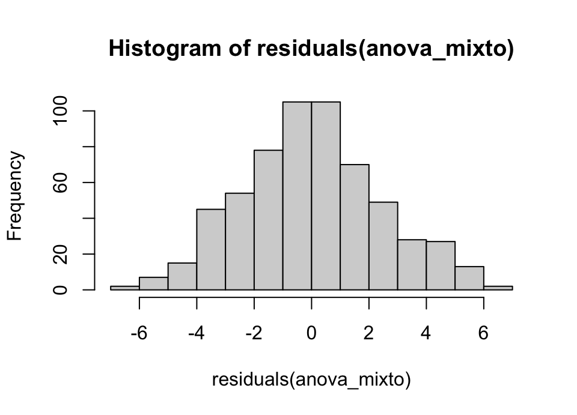

```r
# R base (dia 3): una linea
hist(x = residuals(anova_mixto))
```

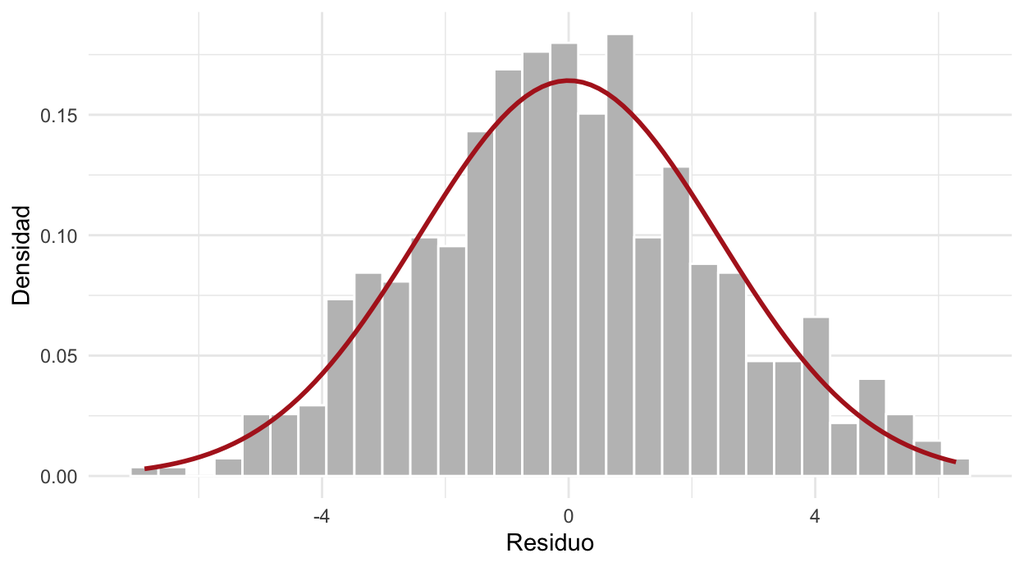

```r
# densidad en vez de conteo, para superponer la normal
ggplot(data = residuos, mapping = aes(x = residuo)) +
  geom_histogram(mapping = aes(y = after_stat(density)),
                 bins = 30, fill = "grey75",
                 color = "white") +
  # la curva normal con la media y la SD de los residuos
  stat_function(fun  = dnorm,
                args = list(mean = mean(residuos$residuo),
                            sd   = sd(residuos$residuo)),
                color = "firebrick", linewidth = 1) +
  labs(x = "Residuo", y = "Densidad") +
  theme_minimal()
```

## Q-Q plot de los residuos: R base vs `ggplot2`

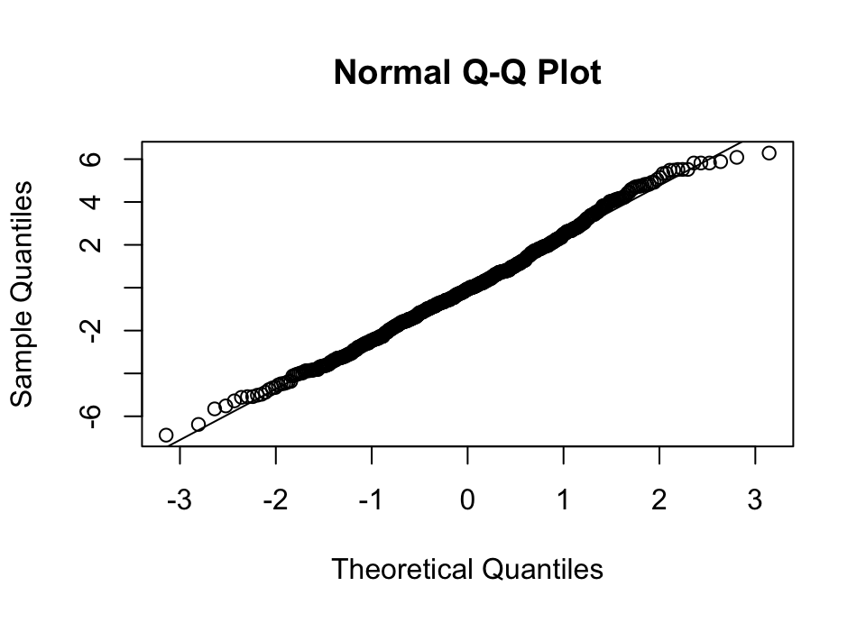

```r
# R base (dia 3): dos lineas
qqnorm(y = residuals(anova_mixto))
qqline(y = residuals(anova_mixto))
```

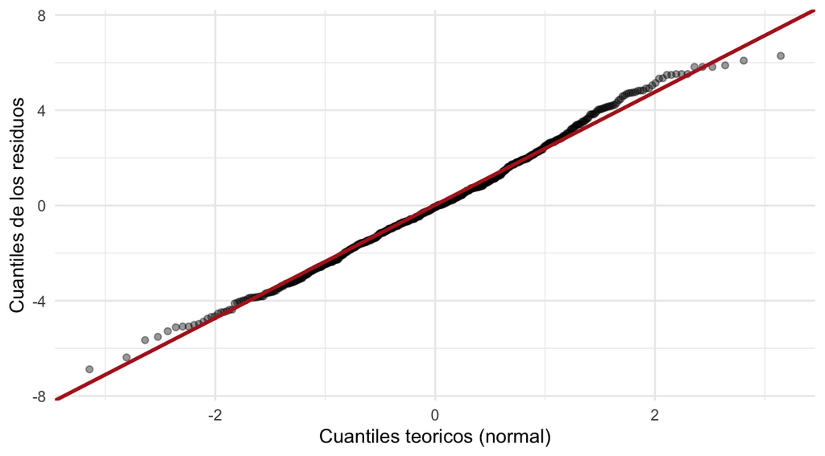

```r
# sample: la variable que se compara con la normal
ggplot(data = residuos, mapping = aes(sample = residuo)) +
  stat_qq(alpha = 0.4) +                      # los puntos
  stat_qq_line(color = "firebrick",   # recta de referencia
               linewidth = 1) +
  labs(x = "Cuantiles teoricos (normal)",
       y = "Cuantiles de los residuos") +
  theme_minimal()
```

## Violin plot — forma de la distribución

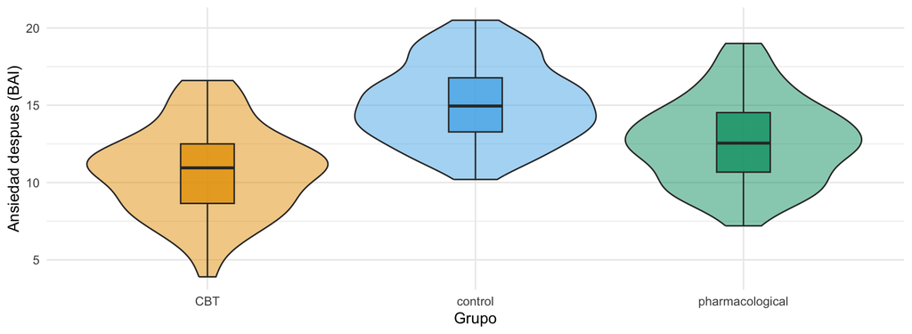

```r
# violin + boxplot combinados: forma de la distribucion + resumen
ggplot(data = data_trial,
       mapping = aes(x = group, y = anxiety_post, fill = group)) +
  geom_violin(alpha = 0.5) +             # la forma: densidad en espejo
  geom_boxplot(width = 0.2,              # estrecho, dentro del violin
               alpha = 0.8) +
  labs(x = "Grupo", y = "Ansiedad despues (BAI)") +
  theme_minimal() +
  theme(legend.position = "none")        # el eje x ya dice el grupo
```

## Gráfico de barras con barras de error

**Código**

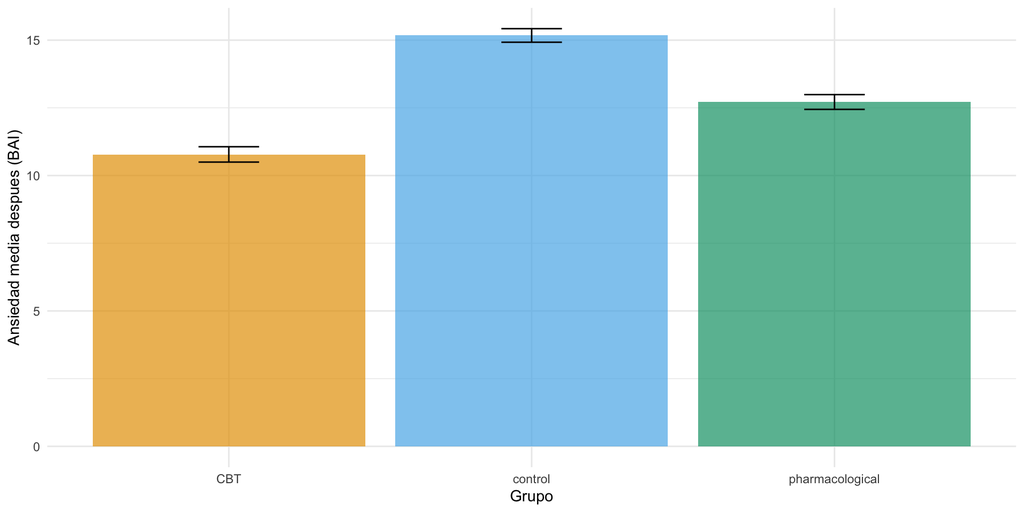

```r
# 1. media y error estandar por grupo: group_by() + summarise() del dia 2
resumen_ansiedad <- data_trial |>
  group_by(group) |>
  summarise(media = mean(anxiety_post),
            ee    = sd(anxiety_post) / sqrt(n()))   # error estandar = dt / raiz(n)

# 2. una barra por grupo (geom_col usa el valor tal cual, no cuenta) + su error
ggplot(data = resumen_ansiedad,
       mapping = aes(x = group, y = media, fill = group)) +
  geom_col(alpha = 0.7) +
  geom_errorbar(mapping = aes(ymin = media - ee,   # extremo inferior: media - 1 EE
                              ymax = media + ee),  # extremo superior: media + 1 EE
                width = 0.2) +                     # anchura de los topes
  labs(x = "Grupo", y = "Ansiedad media despues (BAI)") +
  theme_minimal() +
  theme(legend.position = "none")
```

## El gráfico del ANOVA mixto: pre y post por grupo

**Código**

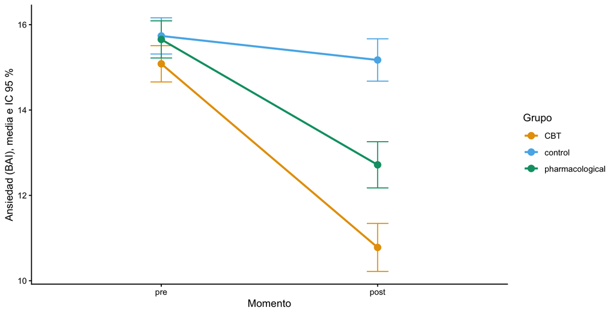

```r
# los datos_largo del Paso 6: stat_summary() resume los datos de cada
# grupo x momento al vuelo (media, intervalo) y los dibuja con el geom que le digas
ggplot(data = datos_largo,
       mapping = aes(x = momento, y = anxiety,
                     color = group,     # un color por grupo
                     group = group)) +  # y una linea por grupo (sin esto no une los puntos)
  stat_summary(fun.data = mean_cl_normal,   # media + IC 95 % (normal)
               geom     = "errorbar",       # dibujado como barra de error
               width    = 0.1) +            # anchura de los topes
  stat_summary(fun       = mean,            # la media...
               geom      = "line",          # ...unida por lineas
               linewidth = 1) +
  stat_summary(fun  = mean,                 # y como punto
               geom = "point",
               size = 3) +
  labs(x = "Momento", y = "Ansiedad (BAI), media e IC 95 %", color = "Grupo") +
  theme_classic()
```

## Raincloud plot: pre y post por grupo (`ggdist`)

Nube (densidad) + caja (resumen) + lluvia (cada paciente): tres capas en un mismo gráfico. Usa los `datos_largo` del Paso 6. El artículo que lo propone: [Allen et al. (2021), *Raincloud plots: a multi-platform tool for robust data visualization*](https://doi.org/10.12688/wellcomeopenres.15191.2).

**Código**

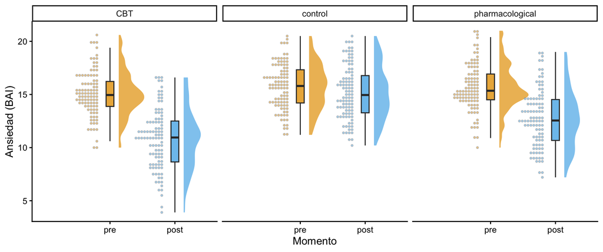

```r
# install.packages("ggdist")
library(ggdist)

grafico_raincloud <- ggplot(data = datos_largo,
                            mapping = aes(x = momento, y = anxiety, fill = momento)) +
  # la NUBE: media densidad, a la derecha de cada momento
  ggdist::stat_halfeye(adjust        = 0.6,    # suavizado de la densidad (< 1 = mas detalle)
                       width         = 0.5,    # anchura maxima de la nube
                       justification = -0.3,   # la desplaza a la derecha, fuera de la caja
                       .width        = 0,      # sin intervalo bajo la nube
                       point_colour  = NA,     # sin el punto de la mediana (lo pone la caja)
                       alpha         = 0.7) +  # transparencia
  # la CAJA: el boxplot de siempre, estrecho
  geom_boxplot(width    = 0.12,        # estrecho, para que quepa entre nube y lluvia
                       outliers = FALSE,       # los extremos ya estan en la lluvia
                       alpha    = 0.8) +
  # la LLUVIA: un punto por paciente, apilados a la izquierda
  ggdist::stat_dots(side          = "left",      # a la izquierda de la caja
                    justification = 1.2,         # la separa de la caja
                    binwidth      = 0.3,         # anchura de cada fila de puntos (en unidades de BAI)
                    dotsize       = 0.9,         # tamano del punto
                    alpha         = 0.5,
                    overflow      = "compress") +  # si no caben, los aprieta en vez de salirse
  facet_wrap(~ group) +                  # un panel por grupo
  labs(x = "Momento", y = "Ansiedad (BAI)") +
  theme_classic(base_size = 14) +
  theme(legend.position = "none")        # el eje x ya dice el momento
grafico_raincloud
```

## Raincloud + las predicciones del modelo

Sobre los datos, lo que el ANOVA mixto del día 3 estima: media de cada grupo en cada momento con su IC 95 % (`emmeans()`), unidas por una línea.

**Código**

```r
library(afex)      # aov_car()
library(emmeans)   # emmeans()

# 1. el modelo del dia 3 y sus medias estimadas por grupo y momento
anova_mixto   <- aov_car(anxiety ~ group * momento + Error(patient_id / momento),
                         data = datos_largo)
medias_modelo <- emmeans(object = anova_mixto,
                         specs  = ~ momento | group) |>   # medias de momento dentro de cada grupo
  as_tibble()                                             # tabla: emmean, lower.CL, upper.CL...

# 2. dos capas mas sobre el raincloud, con los datos del MODELO en vez de los pacientes
grafico_raincloud +
  geom_line(data        = medias_modelo,              # otra tabla para esta capa
            mapping     = aes(x = momento, y = emmean,
                              group = group),         # una linea por grupo
            inherit.aes = FALSE,                      # no hereda fill = momento del raincloud
            color       = "firebrick",             # un color fijo con nombre de R
            linewidth   = 0.9,
            alpha       = 0.8) +
  geom_pointrange(data        = medias_modelo,
                  mapping     = aes(x = momento, y = emmean,
                                    ymin = lower.CL,   # IC 95 % del modelo
                                    ymax = upper.CL),
                  inherit.aes = FALSE,
                  color       = "firebrick",             # un color fijo con nombre de R
                  size        = 0.3,                  # punto pequeno: no tapa el intervalo
                  linewidth   = 1.1,                  # grosor del intervalo
                  alpha       = 0.9)
```

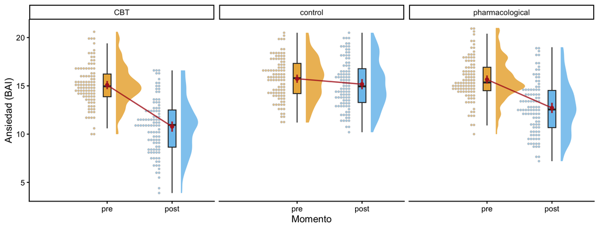

## Estadística en el gráfico: paquetes

Hay paquetes que ponen el resultado de un test **encima** del gráfico (estrellas, corchetes entre grupos). No los usamos en el curso, pero conviene saber que existen:

- [`ggpubr`](https://rpkgs.datanovia.com/ggpubr/): `stat_compare_means()` escribe la *p* del ANOVA o del *t*-test y dibuja los corchetes de cada pareja
- [`ggsignif`](https://const-ae.github.io/ggsignif/): solo los corchetes de significación, como capa de `ggplot2`
- [`ggstatsplot`](https://indrajeetpatil.github.io/ggstatsplot/): gráfico + test completo (estadístico, *p*, tamaño del efecto, *n*) en una línea
- Cuidado: los corchetes por pareja suelen ser *t*-tests **sin corregir**. Para el informe, los post-hoc con `emmeans()` + Holm del día 3

## Resumen del bloque 1

La gramática de `ggplot2`

`ggplot()``aes()``+`

Construir un gráfico

`geom_boxplot()``geom_jitter()``aes(fill = )``alpha =``labs()``theme_classic()``theme_apa()``scale_fill_viridis_d()``facet_wrap()``patchwork: | /``plot_annotation()``ggsave()`

Otros gráficos

`geom_point()``geom_smooth()``geom_histogram()``geom_violin()``geom_col()``geom_errorbar()``stat_summary()``stat_halfeye()``stat_dots()``geom_pointrange()``stat_function()``stat_qq()`